# Impact of Severe weather events in US

HAN

## Synopsis

Although the development of science was extremely grown up, nowadays, there are still many damages from different kinds of weather events. Thus, studying of the pattern of weather events could be one of the most important things we need to continually study about. The goal of this project is what kinds of weather events in United Stated results in most damagable effect. I will use U.S National Oceanic and Atmospheric Administration’s (NOAA) storm database. Although the data includes from 1950, I will use the most recent one (from 1990) considering that the earlier year lack good records. The main quetions for this project is two:

- what weather events are most hamful to population health
- what weather events have the greatest economic consequence

For the first question, I will use the data of the number of *fatalities* and *injuries*. Also, for the second question, I will use the data of *PROPDM* and *CROPDM*. Here is the documentation related to the description of the original data ([link](https://d396qusza40orc.cloudfront.net/repdata%2Fpeer2_doc%2Fpd01016005curr.pdf)).

## Data Processing

```r
#library(R.utils)
if (!"data.csv.bz2" %in% dir("./")) {
        download.file("http://d396qusza40orc.cloudfront.net/repdata%2Fdata%2FStormData.csv.bz2", destfile = "data.csv.bz2")
#        bunzip2("data.csv.bz2", overwrite=T, remove=F)
}
#df<-read.csv("data.csv")
df<-read.csv("data.csv.bz2")
dim(df)
```

```
## [1] 902297     37
```

## Overall histogram

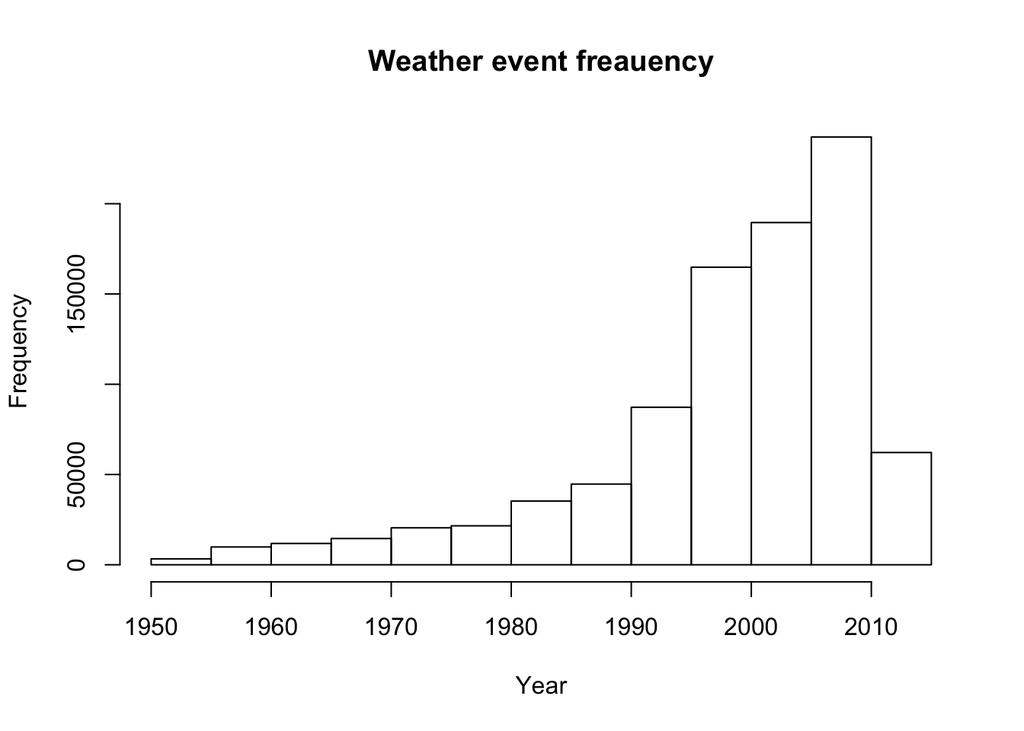

```r
## extract year information
df$year<-as.numeric(format(as.Date(df$BGN_DATE, format = "%m/%d/%Y %H:%M:%S"), "%Y"))
hist(df$year, xlab="Year",main="Weather event freauency")
```

More recent years should considered more complete because old data missed many data. Thus, we will only use the data from 1990-2011.

```r
## More recent years should be considered more complete. -->1990-2011
index<-df$year>=1990
final<-df[index,]
dim(final)
```

```
## [1] 751740     38
```

## Results

#### 1. Across the United States, which types of events (as indicated in the 𝙴𝚅𝚃𝚈𝙿𝙴 variable) are most harmful with respect to population health?

```r
library(plyr)
library(ggplot2)
fat<-ddply(final,.(EVTYPE),summarize,sum=sum(FATALITIES))
fat_order<-fat[order(fat$sum,decreasing = TRUE),]
fat_order<-head(fat_order[fat_order$sum!=0,],10)
fat_order$EVTYPE <- factor(fat_order$EVTYPE, levels = fat_order$EVTYPE[order(fat_order$sum,decreasing = TRUE)])
inj<-ddply(final,.(EVTYPE),summarize,sum=sum(INJURIES))
inj_order<-inj[order(inj$sum,decreasing = TRUE),]
inj_order<-head(inj_order[inj_order$sum!=0,],10)
inj_order$EVTYPE <- factor(inj_order$EVTYPE, levels = inj_order$EVTYPE[order(inj_order$sum,decreasing = TRUE)])
```

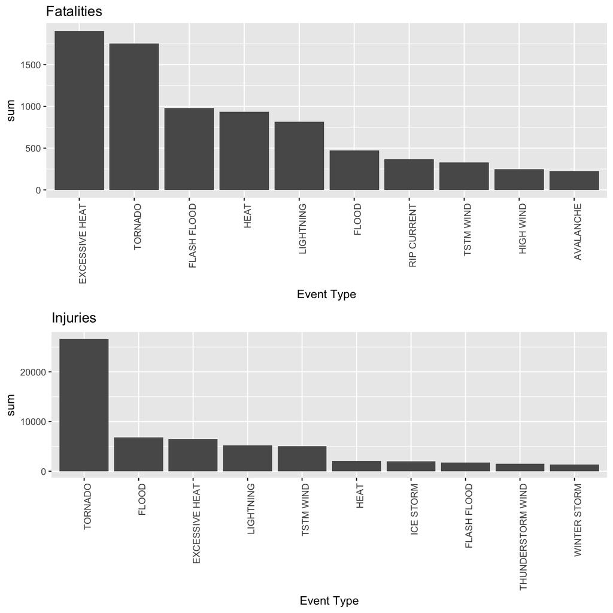

```r
g1 <- ggplot(fat_order,aes(EVTYPE,sum))+geom_bar(stat="identity")+
        theme(axis.text.x = element_text(angle = 90, hjust = 1))+
        labs(x="Event Type")+
        labs(title="Fatalities")
g2 <- ggplot(inj_order,aes(EVTYPE,sum))+geom_bar(stat="identity")+
        theme(axis.text.x = element_text(angle = 90, hjust = 1))+
        labs(x="Event Type")+
        labs(title="Injuries")
library(gridExtra)
grid.arrange(g1,g2,ncol=1)
```

It seems that *Excessive Heat* and *Tornado* dominately affect the number of *fatalities* of people in US. At the same time, *Tornado* also affect the number of *injuriety* dominately.

#### 2. Across the United States, which types of events have the greatest economic consequences?

```r
index1<-final$PROPDMGEXP=="H"
index2<-final$PROPDMGEXP=="K"
index3<-final$PROPDMGEXP=="M"
index4<-final$PROPDMGEXP=="B"

final[index1,]$PROPDMG<-final[index1,]$PROPDMG*10^2
final[index2,]$PROPDMG<-final[index2,]$PROPDMG*10^3
final[index3,]$PROPDMG<-final[index3,]$PROPDMG*10^6
final[index4,]$PROPDMG<-final[index4,]$PROPDMG*10^9

index1<-final$CROPDMGEXP=="H"
index2<-final$CROPDMGEXP=="K"
index3<-final$CROPDMGEXP=="M"
index4<-final$CROPDMGEXP=="B"

final[index1,]$CROPDMG<-final[index1,]$CROPDMG*10^2
final[index2,]$CROPDMG<-final[index2,]$CROPDMG*10^3
final[index3,]$CROPDMG<-final[index3,]$CROPDMG*10^6
final[index4,]$CROPDMG<-final[index4,]$CROPDMG*10^9

pro<-ddply(final,.(EVTYPE),summarize,sum=sum(PROPDMG))
pro_order<-pro[order(pro$sum,decreasing = TRUE),]
pro_order<-head(pro_order[pro_order$sum!=0,],10)
pro_order$EVTYPE <- factor(pro_order$EVTYPE, levels = pro_order$EVTYPE[order(pro_order$sum,decreasing = TRUE)])

cro<-ddply(final,.(EVTYPE),summarize,sum=sum(CROPDMG))
cro_order<-cro[order(cro$sum,decreasing = TRUE),]
cro_order<-head(cro_order[cro_order$sum!=0,],10)
cro_order$EVTYPE <- factor(cro_order$EVTYPE, levels = cro_order$EVTYPE[order(cro_order$sum,decreasing = TRUE)])
```

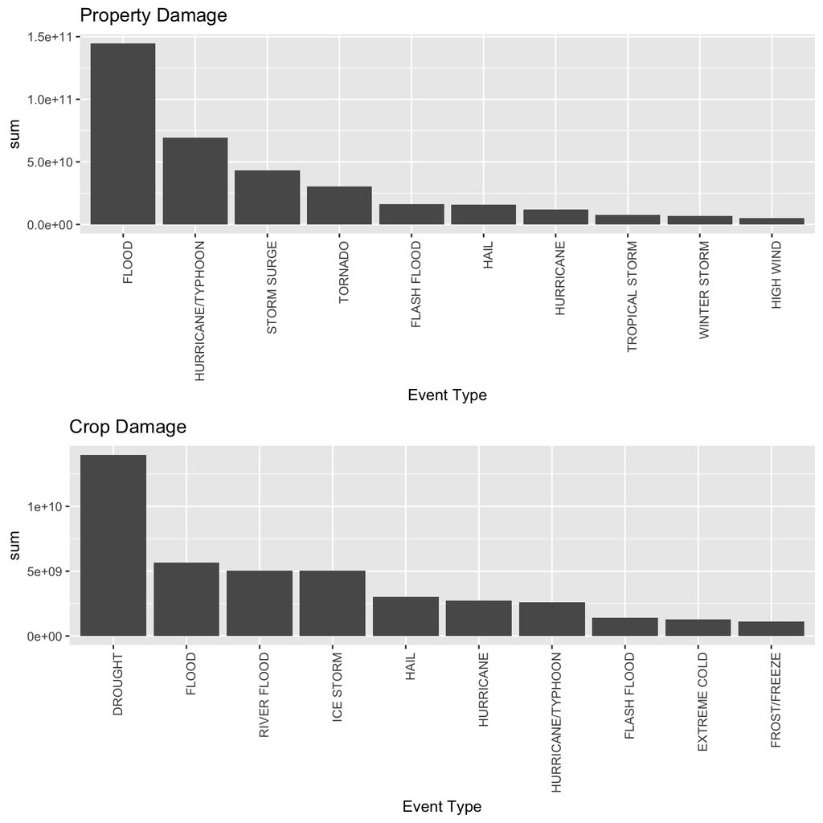

```r
g3<-ggplot(pro_order,aes(EVTYPE,sum))+geom_bar(stat="identity")+
        theme(axis.text.x = element_text(angle = 90, hjust = 1))+
        labs(x="Event Type")+
        labs(title="Property Damage")
g4<-ggplot(cro_order,aes(EVTYPE,sum))+geom_bar(stat="identity")+
        theme(axis.text.x = element_text(angle = 90, hjust = 1))+
        labs(x="Event Type")+
        labs(title="Crop Damage")
grid.arrange(g3,g4,ncol=1)
```

The most damagable severe event is *Flood* while another most damagable event is *Drought*.

## Conclusions

In conclusion, I found that:

- *Excessive heat* and tornado are most harmful for facilities and *tornado* is most harmful for injuries.
- *Flood* is most harmful to property damage and *drought* is most harmful to crop damage in US.